# 1. Data Exploration

```python
# Libraries used in the project


# PostgreSQL (database) adapter
import psycopg2 as pg2

# Connect to local instance PostgreSQl server
from sqlalchemy import create_engine

# Data analysis
import pandas as pd
import numpy as np

# Data Visualizaion
import seaborn as sns
import matplotlib.pyplot as plt

# Storing output on the notebook
%matplotlib inline

# Statistics
from scipy import stats
from scipy.stats import kruskal
from sklearn.model_selection import RandomizedSearchCV
from scipy.stats import randint

# Transform the categorical data into one-hot encoded
from sklearn.preprocessing import OneHotEncoder

# Data splitting
from sklearn.model_selection import train_test_split
from sklearn.preprocessing import StandardScaler
from sklearn.preprocessing import MinMaxScaler

# Model buiding Regression
from sklearn.ensemble import RandomForestRegressor
from sklearn.neural_network import MLPRegressor


# Evaluating model performance in regression
from sklearn.metrics import mean_absolute_error
from sklearn.metrics import mean_squared_error
from sklearn.metrics import r2_score
from sklearn.model_selection import RandomizedSearchCV
from scipy.stats import randint


from sklearn.ensemble import RandomForestRegressor
from sklearn.metrics import mean_squared_error
from sklearn.model_selection import train_test_split
import pandas as pd
from sklearn.model_selection import cross_val_score


from sklearn.model_selection import RandomizedSearchCV
from scipy.stats import randint


# Neural Network
import keras
from keras import models
from keras import layers
from keras import optimizers
from keras.models import Sequential
from keras.layers import Dense, Activation, Dropout
from keras.regularizers import l2
import warnings
warnings.filterwarnings(action='ignore')

# Loading data from local database (PostgreSQL) and creating dataframe
engine = create_engine('postgresql://postgres:..Aberdeen22@localhost:5432/mimic')
df = pd.read_sql("select * from mimiciii.admissions \
INNER JOIN mimiciii.patients \
ON admissions.subject_id = patients.subject_id", engine)
```

```python
# Checking first 5 rows of the dataframe

df.head(5)
```

|  | row_id | subject_id | hadm_id | admittime | dischtime | deathtime | admission_type | admission_location | discharge_location | insurance | ... | hospital_expire_flag | has_chartevents_data | row_id | subject_id | gender | dob | dod | dod_hosp | dod_ssn | expire_flag |
| --- | --- | --- | --- | --- | --- | --- | --- | --- | --- | --- | --- | --- | --- | --- | --- | --- | --- | --- | --- | --- | --- |
| 0 | 21 | 22 | 165315 | 2196-04-09 12:26:00 | 2196-04-10 15:54:00 | NaT | EMERGENCY | EMERGENCY ROOM ADMIT | DISC-TRAN CANCER/CHLDRN H | Private | ... | 0 | 1 | 19 | 22 | F | 2131-05-07 | NaT | NaT | NaT | 0 |
| 1 | 22 | 23 | 152223 | 2153-09-03 07:15:00 | 2153-09-08 19:10:00 | NaT | ELECTIVE | PHYS REFERRAL/NORMAL DELI | HOME HEALTH CARE | Medicare | ... | 0 | 1 | 20 | 23 | M | 2082-07-17 | NaT | NaT | NaT | 0 |
| 2 | 23 | 23 | 124321 | 2157-10-18 19:34:00 | 2157-10-25 14:00:00 | NaT | EMERGENCY | TRANSFER FROM HOSP/EXTRAM | HOME HEALTH CARE | Medicare | ... | 0 | 1 | 20 | 23 | M | 2082-07-17 | NaT | NaT | NaT | 0 |
| 3 | 24 | 24 | 161859 | 2139-06-06 16:14:00 | 2139-06-09 12:48:00 | NaT | EMERGENCY | TRANSFER FROM HOSP/EXTRAM | HOME | Private | ... | 0 | 1 | 21 | 24 | M | 2100-05-31 | NaT | NaT | NaT | 0 |
| 4 | 25 | 25 | 129635 | 2160-11-02 02:06:00 | 2160-11-05 14:55:00 | NaT | EMERGENCY | EMERGENCY ROOM ADMIT | HOME | Private | ... | 0 | 1 | 22 | 25 | M | 2101-11-21 | NaT | NaT | NaT | 0 |

5 rows × 27 columns

```python
# Verifing dataframe shape (rows and columns)

df.shape
```

```
(58976, 27)
```

```python
# Checking Type of Data in the Dataframe

df.dtypes
```

```
row_id                           int64
subject_id                       int64
hadm_id                          int64
admittime               datetime64[ns]
dischtime               datetime64[ns]
deathtime               datetime64[ns]
admission_type                  object
admission_location              object
discharge_location              object
insurance                       object
language                        object
religion                        object
marital_status                  object
ethnicity                       object
edregtime               datetime64[ns]
edouttime               datetime64[ns]
diagnosis                       object
hospital_expire_flag             int64
has_chartevents_data             int64
row_id                           int64
subject_id                       int64
gender                          object
dob                     datetime64[ns]
dod                     datetime64[ns]
dod_hosp                datetime64[ns]
dod_ssn                 datetime64[ns]
expire_flag                      int64
dtype: object
```

```python
# Finding number of missing values in the columns

df.isna().sum()
```

```
row_id                      0
subject_id                  0
hadm_id                     0
admittime                   0
dischtime                   0
deathtime               53122
admission_type              0
admission_location          0
discharge_location          0
insurance                   0
language                25332
religion                  458
marital_status          10128
ethnicity                   0
edregtime               28099
edouttime               28099
diagnosis                  25
hospital_expire_flag        0
has_chartevents_data        0
row_id                      0
subject_id                  0
gender                      0
dob                         0
dod                     36390
dod_hosp                43905
dod_ssn                 39907
expire_flag                 0
dtype: int64
```

```python
# Handling missing values in the numerical data
# Filling missing data in the dataframe with the next row data

df[['deathtime',
    'edregtime',
    'edouttime',
    'dod',
    'dod_hosp', 'dod_ssn']] = df[['deathtime',
                                  'edregtime',
                                  'edouttime',
                                  'dod',
                                  'dod_hosp',
                                  'dod_ssn']].fillna(df[['deathtime',
                                                         'language',
                                                         'religion',
                                                         'marital_status',
                                                         'edregtime',
                                                         'edouttime',
                                                         'diagnosis',
                                                         'dod',
                                                         'dod_hosp', 'dod_ssn']]).fillna(method='bfill')
```

```python
# Checking the most common language

df['language'].value_counts()
```

```
ENGL    29086
SPAN     1083
RUSS      790
PTUN      628
CANT      413
        ...
* FU        1
*SPA        1
*RUS        1
*ROM        1
*TAM        1
Name: language, Length: 75, dtype: int64
```

```python
# Replacing missing values with the most common language

df['language'] = df['language'].fillna('ENGL')
```

```python
# Identifying the most common religion

df['religion'].value_counts()
```

```
CATHOLIC                  20606
NOT SPECIFIED             11753
UNOBTAINABLE               8269
PROTESTANT QUAKER          7134
JEWISH                     5314
OTHER                      2696
EPISCOPALIAN                774
GREEK ORTHODOX              459
CHRISTIAN SCIENTIST         429
BUDDHIST                    267
MUSLIM                      225
JEHOVAH'S WITNESS           139
UNITARIAN-UNIVERSALIST      124
HINDU                       113
ROMANIAN EAST. ORTH          83
7TH DAY ADVENTIST            81
BAPTIST                      28
HEBREW                       16
METHODIST                     7
LUTHERAN                      1
Name: religion, dtype: int64
```

```python
# Replacing missing values with the most common religion

df['religion'] = df['religion'].fillna('CATHOLIC')
```

```python
# Verifying the most common marital status

df['marital_status'].value_counts()
```

```
MARRIED              24239
SINGLE               13254
WIDOWED               7211
DIVORCED              3213
SEPARATED              571
UNKNOWN (DEFAULT)      345
LIFE PARTNER            15
Name: marital_status, dtype: int64
```

```python
# Replacing missing values with the most common material status

df['marital_status'] = df['marital_status'].fillna('MARRIED')
```

```python
# Checking the most common diagnosis

df['diagnosis'].value_counts()
```

```
NEWBORN                                  7823
PNEUMONIA                                1566
SEPSIS                                   1184
CONGESTIVE HEART FAILURE                  928
CORONARY ARTERY DISEASE                   840
                                         ...
DIAPHRAGM RUPTURE                           1
RIGHT ANTERIOR CEREBRAL ARTERY STROKE       1
HYPOXIA, ACUTE RENAL FAILURE                1
S/P MOTOR VECHICLE ACCIDENT                 1
JOINT EFFUSION                              1
Name: diagnosis, Length: 15682, dtype: int64
```

```python
# Replacing missing values with the most common diagnosis

df['diagnosis'] = df['diagnosis'].fillna('NEWBORN')
```

```python
# Checking for missing values in categorical variables

df.isnull().sum()
```

```
row_id                  0
subject_id              0
hadm_id                 0
admittime               0
dischtime               0
deathtime               3
admission_type          0
admission_location      0
discharge_location      0
insurance               0
language                0
religion                0
marital_status          0
ethnicity               0
edregtime               0
edouttime               0
diagnosis               0
hospital_expire_flag    0
has_chartevents_data    0
row_id                  0
subject_id              0
gender                  0
dob                     0
dod                     3
dod_hosp                3
dod_ssn                 8
expire_flag             0
dtype: int64
```

```python
# Filling missing data (numerical) in the dataframe with the previous row data

df[['deathtime',
    'dod',
    'dod_hosp','dod_ssn']] = df[['deathtime',
                                 'dod',
                                 'dod_hosp','dod_ssn']].fillna(df[['deathtime',
                                                                   'dod',
                                                                   'dod_hosp', 'dod_ssn']]).fillna(method='ffill')
```

```python
df.isnull().sum()
```

```
row_id                  0
subject_id              0
hadm_id                 0
admittime               0
dischtime               0
deathtime               0
admission_type          0
admission_location      0
discharge_location      0
insurance               0
language                0
religion                0
marital_status          0
ethnicity               0
edregtime               0
edouttime               0
diagnosis               0
hospital_expire_flag    0
has_chartevents_data    0
row_id                  0
subject_id              0
gender                  0
dob                     0
dod                     0
dod_hosp                0
dod_ssn                 0
expire_flag             0
dtype: int64
```

```python
# Visualising the dataframe

df
```

|  | row_id | subject_id | hadm_id | admittime | dischtime | deathtime | admission_type | admission_location | discharge_location | insurance | ... | hospital_expire_flag | has_chartevents_data | row_id | subject_id | gender | dob | dod | dod_hosp | dod_ssn | expire_flag |
| --- | --- | --- | --- | --- | --- | --- | --- | --- | --- | --- | --- | --- | --- | --- | --- | --- | --- | --- | --- | --- | --- |
| 0 | 21 | 22 | 165315 | 2196-04-09 12:26:00 | 2196-04-10 15:54:00 | 2108-08-30 15:00:00 | EMERGENCY | EMERGENCY ROOM ADMIT | DISC-TRAN CANCER/CHLDRN H | Private | ... | 0 | 1 | 19 | 22 | F | 2131-05-07 | 2128-02-25 | 2108-08-30 | 2128-02-25 | 0 |
| 1 | 22 | 23 | 152223 | 2153-09-03 07:15:00 | 2153-09-08 19:10:00 | 2108-08-30 15:00:00 | ELECTIVE | PHYS REFERRAL/NORMAL DELI | HOME HEALTH CARE | Medicare | ... | 0 | 1 | 20 | 23 | M | 2082-07-17 | 2128-02-25 | 2108-08-30 | 2128-02-25 | 0 |
| 2 | 23 | 23 | 124321 | 2157-10-18 19:34:00 | 2157-10-25 14:00:00 | 2108-08-30 15:00:00 | EMERGENCY | TRANSFER FROM HOSP/EXTRAM | HOME HEALTH CARE | Medicare | ... | 0 | 1 | 20 | 23 | M | 2082-07-17 | 2128-02-25 | 2108-08-30 | 2128-02-25 | 0 |
| 3 | 24 | 24 | 161859 | 2139-06-06 16:14:00 | 2139-06-09 12:48:00 | 2108-08-30 15:00:00 | EMERGENCY | TRANSFER FROM HOSP/EXTRAM | HOME | Private | ... | 0 | 1 | 21 | 24 | M | 2100-05-31 | 2128-02-25 | 2108-08-30 | 2128-02-25 | 0 |
| 4 | 25 | 25 | 129635 | 2160-11-02 02:06:00 | 2160-11-05 14:55:00 | 2108-08-30 15:00:00 | EMERGENCY | EMERGENCY ROOM ADMIT | HOME | Private | ... | 0 | 1 | 22 | 25 | M | 2101-11-21 | 2128-02-25 | 2108-08-30 | 2128-02-25 | 0 |
| ... | ... | ... | ... | ... | ... | ... | ... | ... | ... | ... | ... | ... | ... | ... | ... | ... | ... | ... | ... | ... | ... |
| 58971 | 58594 | 98800 | 191113 | 2131-03-30 21:13:00 | 2131-04-02 15:02:00 | 2151-03-06 09:10:00 | EMERGENCY | CLINIC REFERRAL/PREMATURE | HOME | Private | ... | 0 | 1 | 46213 | 98800 | F | 2111-11-05 | 2151-03-06 | 2151-03-06 | 2125-04-06 | 0 |
| 58972 | 58595 | 98802 | 101071 | 2151-03-05 20:00:00 | 2151-03-06 09:10:00 | 2151-03-06 09:10:00 | EMERGENCY | CLINIC REFERRAL/PREMATURE | DEAD/EXPIRED | Medicare | ... | 1 | 1 | 46214 | 98802 | F | 2067-09-21 | 2151-03-06 | 2151-03-06 | 2125-04-06 | 1 |
| 58973 | 58596 | 98805 | 122631 | 2200-09-12 07:15:00 | 2200-09-20 12:08:00 | 2151-03-06 09:10:00 | ELECTIVE | PHYS REFERRAL/NORMAL DELI | HOME HEALTH CARE | Private | ... | 0 | 1 | 46215 | 98805 | M | 2158-03-02 | 2151-03-06 | 2151-03-06 | 2125-04-06 | 0 |
| 58974 | 58597 | 98813 | 170407 | 2128-11-11 02:29:00 | 2128-12-22 13:11:00 | 2151-03-06 09:10:00 | EMERGENCY | EMERGENCY ROOM ADMIT | SNF | Private | ... | 0 | 0 | 46216 | 98813 | F | 2068-02-04 | 2151-03-06 | 2151-03-06 | 2125-04-06 | 0 |
| 58975 | 58598 | 98813 | 190264 | 2131-10-25 03:09:00 | 2131-10-26 17:44:00 | 2151-03-06 09:10:00 | EMERGENCY | CLINIC REFERRAL/PREMATURE | HOME | Private | ... | 0 | 1 | 46216 | 98813 | F | 2068-02-04 | 2151-03-06 | 2151-03-06 | 2125-04-06 | 0 |

58976 rows × 27 columns

```python
# Calculating length of stay from difference (subtraction) between Discharge Time and Admission Time
#(Length of Stay = Discharge Time - Admission Time)

def diff(a, b):
    return b - a

df['length_of_stay'] = df.apply(
    lambda x: diff(x['admittime'], x['dischtime']), axis=1)

df
```

|  | row_id | subject_id | hadm_id | admittime | dischtime | deathtime | admission_type | admission_location | discharge_location | insurance | ... | has_chartevents_data | row_id | subject_id | gender | dob | dod | dod_hosp | dod_ssn | expire_flag | length_of_stay |
| --- | --- | --- | --- | --- | --- | --- | --- | --- | --- | --- | --- | --- | --- | --- | --- | --- | --- | --- | --- | --- | --- |
| 0 | 21 | 22 | 165315 | 2196-04-09 12:26:00 | 2196-04-10 15:54:00 | 2108-08-30 15:00:00 | EMERGENCY | EMERGENCY ROOM ADMIT | DISC-TRAN CANCER/CHLDRN H | Private | ... | 1 | 19 | 22 | F | 2131-05-07 | 2128-02-25 | 2108-08-30 | 2128-02-25 | 0 | 1 days 03:28:00 |
| 1 | 22 | 23 | 152223 | 2153-09-03 07:15:00 | 2153-09-08 19:10:00 | 2108-08-30 15:00:00 | ELECTIVE | PHYS REFERRAL/NORMAL DELI | HOME HEALTH CARE | Medicare | ... | 1 | 20 | 23 | M | 2082-07-17 | 2128-02-25 | 2108-08-30 | 2128-02-25 | 0 | 5 days 11:55:00 |
| 2 | 23 | 23 | 124321 | 2157-10-18 19:34:00 | 2157-10-25 14:00:00 | 2108-08-30 15:00:00 | EMERGENCY | TRANSFER FROM HOSP/EXTRAM | HOME HEALTH CARE | Medicare | ... | 1 | 20 | 23 | M | 2082-07-17 | 2128-02-25 | 2108-08-30 | 2128-02-25 | 0 | 6 days 18:26:00 |
| 3 | 24 | 24 | 161859 | 2139-06-06 16:14:00 | 2139-06-09 12:48:00 | 2108-08-30 15:00:00 | EMERGENCY | TRANSFER FROM HOSP/EXTRAM | HOME | Private | ... | 1 | 21 | 24 | M | 2100-05-31 | 2128-02-25 | 2108-08-30 | 2128-02-25 | 0 | 2 days 20:34:00 |
| 4 | 25 | 25 | 129635 | 2160-11-02 02:06:00 | 2160-11-05 14:55:00 | 2108-08-30 15:00:00 | EMERGENCY | EMERGENCY ROOM ADMIT | HOME | Private | ... | 1 | 22 | 25 | M | 2101-11-21 | 2128-02-25 | 2108-08-30 | 2128-02-25 | 0 | 3 days 12:49:00 |
| ... | ... | ... | ... | ... | ... | ... | ... | ... | ... | ... | ... | ... | ... | ... | ... | ... | ... | ... | ... | ... | ... |
| 58971 | 58594 | 98800 | 191113 | 2131-03-30 21:13:00 | 2131-04-02 15:02:00 | 2151-03-06 09:10:00 | EMERGENCY | CLINIC REFERRAL/PREMATURE | HOME | Private | ... | 1 | 46213 | 98800 | F | 2111-11-05 | 2151-03-06 | 2151-03-06 | 2125-04-06 | 0 | 2 days 17:49:00 |
| 58972 | 58595 | 98802 | 101071 | 2151-03-05 20:00:00 | 2151-03-06 09:10:00 | 2151-03-06 09:10:00 | EMERGENCY | CLINIC REFERRAL/PREMATURE | DEAD/EXPIRED | Medicare | ... | 1 | 46214 | 98802 | F | 2067-09-21 | 2151-03-06 | 2151-03-06 | 2125-04-06 | 1 | 0 days 13:10:00 |
| 58973 | 58596 | 98805 | 122631 | 2200-09-12 07:15:00 | 2200-09-20 12:08:00 | 2151-03-06 09:10:00 | ELECTIVE | PHYS REFERRAL/NORMAL DELI | HOME HEALTH CARE | Private | ... | 1 | 46215 | 98805 | M | 2158-03-02 | 2151-03-06 | 2151-03-06 | 2125-04-06 | 0 | 8 days 04:53:00 |
| 58974 | 58597 | 98813 | 170407 | 2128-11-11 02:29:00 | 2128-12-22 13:11:00 | 2151-03-06 09:10:00 | EMERGENCY | EMERGENCY ROOM ADMIT | SNF | Private | ... | 0 | 46216 | 98813 | F | 2068-02-04 | 2151-03-06 | 2151-03-06 | 2125-04-06 | 0 | 41 days 10:42:00 |
| 58975 | 58598 | 98813 | 190264 | 2131-10-25 03:09:00 | 2131-10-26 17:44:00 | 2151-03-06 09:10:00 | EMERGENCY | CLINIC REFERRAL/PREMATURE | HOME | Private | ... | 1 | 46216 | 98813 | F | 2068-02-04 | 2151-03-06 | 2151-03-06 | 2125-04-06 | 0 | 1 days 14:35:00 |

58976 rows × 28 columns

```python
# Converting length of stay data to days only

df['length_of_stay'] = df['length_of_stay'].dt.days

df.head()
```

|  | row_id | subject_id | hadm_id | admittime | dischtime | deathtime | admission_type | admission_location | discharge_location | insurance | ... | has_chartevents_data | row_id | subject_id | gender | dob | dod | dod_hosp | dod_ssn | expire_flag | length_of_stay |
| --- | --- | --- | --- | --- | --- | --- | --- | --- | --- | --- | --- | --- | --- | --- | --- | --- | --- | --- | --- | --- | --- |
| 0 | 21 | 22 | 165315 | 2196-04-09 12:26:00 | 2196-04-10 15:54:00 | 2108-08-30 15:00:00 | EMERGENCY | EMERGENCY ROOM ADMIT | DISC-TRAN CANCER/CHLDRN H | Private | ... | 1 | 19 | 22 | F | 2131-05-07 | 2128-02-25 | 2108-08-30 | 2128-02-25 | 0 | 1 |
| 1 | 22 | 23 | 152223 | 2153-09-03 07:15:00 | 2153-09-08 19:10:00 | 2108-08-30 15:00:00 | ELECTIVE | PHYS REFERRAL/NORMAL DELI | HOME HEALTH CARE | Medicare | ... | 1 | 20 | 23 | M | 2082-07-17 | 2128-02-25 | 2108-08-30 | 2128-02-25 | 0 | 5 |
| 2 | 23 | 23 | 124321 | 2157-10-18 19:34:00 | 2157-10-25 14:00:00 | 2108-08-30 15:00:00 | EMERGENCY | TRANSFER FROM HOSP/EXTRAM | HOME HEALTH CARE | Medicare | ... | 1 | 20 | 23 | M | 2082-07-17 | 2128-02-25 | 2108-08-30 | 2128-02-25 | 0 | 6 |
| 3 | 24 | 24 | 161859 | 2139-06-06 16:14:00 | 2139-06-09 12:48:00 | 2108-08-30 15:00:00 | EMERGENCY | TRANSFER FROM HOSP/EXTRAM | HOME | Private | ... | 1 | 21 | 24 | M | 2100-05-31 | 2128-02-25 | 2108-08-30 | 2128-02-25 | 0 | 2 |
| 4 | 25 | 25 | 129635 | 2160-11-02 02:06:00 | 2160-11-05 14:55:00 | 2108-08-30 15:00:00 | EMERGENCY | EMERGENCY ROOM ADMIT | HOME | Private | ... | 1 | 22 | 25 | M | 2101-11-21 | 2128-02-25 | 2108-08-30 | 2128-02-25 | 0 | 3 |

5 rows × 28 columns

```python
#category=pd.cut(df.LOS,bins=[0,5,10,294],labels=['Short','Medium','Long'])
#df.insert(29,'los_group',category)

#df
```

```python
# Converting date of birth (dob) to date
df['dob'] = pd.to_datetime(df['dob']).dt.date

# Converting admission date (admittime) to date
df['admittime'] = pd.to_datetime(df['admittime']).dt.date

# Calculating patient age (age = admission time - date of birth)
df['age'] = df.apply(lambda e: (e['admittime'] - e['dob']).days/365, axis=1)

# Returning 89 to all values greater than 89 in the age column
df['age'] = df['age'].apply(lambda x: 89 if x > 89 else x).astype('int')
```

```python
#df['age'] = df['age'].apply(lambda x: 0 if x < 0 else x).astype('int')
```

```python
# Categorising age by group (Children, Young Adults, Adults and Senior) and create a new column for it

df['age_group'] = pd.cut(df['age'], bins=[0, 15, 30, 60, 90], labels=['Children', 'Young Adults', 'Adults', 'Senior'])

df
```

|  | row_id | subject_id | hadm_id | admittime | dischtime | deathtime | admission_type | admission_location | discharge_location | insurance | ... | subject_id | gender | dob | dod | dod_hosp | dod_ssn | expire_flag | length_of_stay | age | age_group |
| --- | --- | --- | --- | --- | --- | --- | --- | --- | --- | --- | --- | --- | --- | --- | --- | --- | --- | --- | --- | --- | --- |
| 0 | 21 | 22 | 165315 | 2196-04-09 | 2196-04-10 15:54:00 | 2108-08-30 15:00:00 | EMERGENCY | EMERGENCY ROOM ADMIT | DISC-TRAN CANCER/CHLDRN H | Private | ... | 22 | F | 2131-05-07 | 2128-02-25 | 2108-08-30 | 2128-02-25 | 0 | 1 | 64 | Senior |
| 1 | 22 | 23 | 152223 | 2153-09-03 | 2153-09-08 19:10:00 | 2108-08-30 15:00:00 | ELECTIVE | PHYS REFERRAL/NORMAL DELI | HOME HEALTH CARE | Medicare | ... | 23 | M | 2082-07-17 | 2128-02-25 | 2108-08-30 | 2128-02-25 | 0 | 5 | 71 | Senior |
| 2 | 23 | 23 | 124321 | 2157-10-18 | 2157-10-25 14:00:00 | 2108-08-30 15:00:00 | EMERGENCY | TRANSFER FROM HOSP/EXTRAM | HOME HEALTH CARE | Medicare | ... | 23 | M | 2082-07-17 | 2128-02-25 | 2108-08-30 | 2128-02-25 | 0 | 6 | 75 | Senior |
| 3 | 24 | 24 | 161859 | 2139-06-06 | 2139-06-09 12:48:00 | 2108-08-30 15:00:00 | EMERGENCY | TRANSFER FROM HOSP/EXTRAM | HOME | Private | ... | 24 | M | 2100-05-31 | 2128-02-25 | 2108-08-30 | 2128-02-25 | 0 | 2 | 39 | Adults |
| 4 | 25 | 25 | 129635 | 2160-11-02 | 2160-11-05 14:55:00 | 2108-08-30 15:00:00 | EMERGENCY | EMERGENCY ROOM ADMIT | HOME | Private | ... | 25 | M | 2101-11-21 | 2128-02-25 | 2108-08-30 | 2128-02-25 | 0 | 3 | 58 | Adults |
| ... | ... | ... | ... | ... | ... | ... | ... | ... | ... | ... | ... | ... | ... | ... | ... | ... | ... | ... | ... | ... | ... |
| 58971 | 58594 | 98800 | 191113 | 2131-03-30 | 2131-04-02 15:02:00 | 2151-03-06 09:10:00 | EMERGENCY | CLINIC REFERRAL/PREMATURE | HOME | Private | ... | 98800 | F | 2111-11-05 | 2151-03-06 | 2151-03-06 | 2125-04-06 | 0 | 2 | 19 | Young Adults |
| 58972 | 58595 | 98802 | 101071 | 2151-03-05 | 2151-03-06 09:10:00 | 2151-03-06 09:10:00 | EMERGENCY | CLINIC REFERRAL/PREMATURE | DEAD/EXPIRED | Medicare | ... | 98802 | F | 2067-09-21 | 2151-03-06 | 2151-03-06 | 2125-04-06 | 1 | 0 | 83 | Senior |
| 58973 | 58596 | 98805 | 122631 | 2200-09-12 | 2200-09-20 12:08:00 | 2151-03-06 09:10:00 | ELECTIVE | PHYS REFERRAL/NORMAL DELI | HOME HEALTH CARE | Private | ... | 98805 | M | 2158-03-02 | 2151-03-06 | 2151-03-06 | 2125-04-06 | 0 | 8 | 42 | Adults |
| 58974 | 58597 | 98813 | 170407 | 2128-11-11 | 2128-12-22 13:11:00 | 2151-03-06 09:10:00 | EMERGENCY | EMERGENCY ROOM ADMIT | SNF | Private | ... | 98813 | F | 2068-02-04 | 2151-03-06 | 2151-03-06 | 2125-04-06 | 0 | 41 | 60 | Adults |
| 58975 | 58598 | 98813 | 190264 | 2131-10-25 | 2131-10-26 17:44:00 | 2151-03-06 09:10:00 | EMERGENCY | CLINIC REFERRAL/PREMATURE | HOME | Private | ... | 98813 | F | 2068-02-04 | 2151-03-06 | 2151-03-06 | 2125-04-06 | 0 | 1 | 63 | Senior |

58976 rows × 30 columns

```python
# Checking missing values

df.isnull().sum()
```

```
row_id                     0
subject_id                 0
hadm_id                    0
admittime                  0
dischtime                  0
deathtime                  0
admission_type             0
admission_location         0
discharge_location         0
insurance                  0
language                   0
religion                   0
marital_status             0
ethnicity                  0
edregtime                  0
edouttime                  0
diagnosis                  0
hospital_expire_flag       0
has_chartevents_data       0
row_id                     0
subject_id                 0
gender                     0
dob                        0
dod                        0
dod_hosp                   0
dod_ssn                    0
expire_flag                0
length_of_stay             0
age                        0
age_group               8110
dtype: int64
```

```python
# Verifying the most common age group categories

df['age_group'].value_counts()
```

```
Senior          30347
Adults          17882
Young Adults     2628
Children            9
Name: age_group, dtype: int64
```

```python
# Replacing missiong values with the most common age group

df['age_group'] = df['age_group'].fillna('Senior')
```

```python
# Checking missing values

df.isnull().sum()
```

```
row_id                  0
subject_id              0
hadm_id                 0
admittime               0
dischtime               0
deathtime               0
admission_type          0
admission_location      0
discharge_location      0
insurance               0
language                0
religion                0
marital_status          0
ethnicity               0
edregtime               0
edouttime               0
diagnosis               0
hospital_expire_flag    0
has_chartevents_data    0
row_id                  0
subject_id              0
gender                  0
dob                     0
dod                     0
dod_hosp                0
dod_ssn                 0
expire_flag             0
length_of_stay          0
age                     0
age_group               0
dtype: int64
```

```python
# Identifying categorical data to recategorise it

df.dtypes
```

```
row_id                           int64
subject_id                       int64
hadm_id                          int64
admittime                       object
dischtime               datetime64[ns]
deathtime               datetime64[ns]
admission_type                  object
admission_location              object
discharge_location              object
insurance                       object
language                        object
religion                        object
marital_status                  object
ethnicity                       object
edregtime               datetime64[ns]
edouttime               datetime64[ns]
diagnosis                       object
hospital_expire_flag             int64
has_chartevents_data             int64
row_id                           int64
subject_id                       int64
gender                          object
dob                             object
dod                     datetime64[ns]
dod_hosp                datetime64[ns]
dod_ssn                 datetime64[ns]
expire_flag                      int64
length_of_stay                   int64
age                              int32
age_group                     category
dtype: object
```

```python
# Checking ethnicity categories counts

df['ethnicity'].value_counts()
```

```
WHITE                                                       40996
BLACK/AFRICAN AMERICAN                                       5440
UNKNOWN/NOT SPECIFIED                                        4523
HISPANIC OR LATINO                                           1696
OTHER                                                        1512
ASIAN                                                        1509
UNABLE TO OBTAIN                                              814
PATIENT DECLINED TO ANSWER                                    559
ASIAN - CHINESE                                               277
HISPANIC/LATINO - PUERTO RICAN                                232
BLACK/CAPE VERDEAN                                            200
WHITE - RUSSIAN                                               164
MULTI RACE ETHNICITY                                          130
BLACK/HAITIAN                                                 101
ASIAN - ASIAN INDIAN                                           85
WHITE - OTHER EUROPEAN                                         81
HISPANIC/LATINO - DOMINICAN                                    78
PORTUGUESE                                                     61
WHITE - BRAZILIAN                                              59
ASIAN - VIETNAMESE                                             53
AMERICAN INDIAN/ALASKA NATIVE                                  51
BLACK/AFRICAN                                                  44
MIDDLE EASTERN                                                 43
HISPANIC/LATINO - GUATEMALAN                                   40
WHITE - EASTERN EUROPEAN                                       25
ASIAN - FILIPINO                                               25
HISPANIC/LATINO - CUBAN                                        24
HISPANIC/LATINO - SALVADORAN                                   19
NATIVE HAWAIIAN OR OTHER PACIFIC ISLANDER                      18
ASIAN - OTHER                                                  17
ASIAN - CAMBODIAN                                              17
ASIAN - KOREAN                                                 13
HISPANIC/LATINO - CENTRAL AMERICAN (OTHER)                     13
HISPANIC/LATINO - MEXICAN                                      13
HISPANIC/LATINO - COLOMBIAN                                     9
CARIBBEAN ISLAND                                                9
SOUTH AMERICAN                                                  8
ASIAN - JAPANESE                                                7
ASIAN - THAI                                                    4
HISPANIC/LATINO - HONDURAN                                      4
AMERICAN INDIAN/ALASKA NATIVE FEDERALLY RECOGNIZED TRIBE        3
Name: ethnicity, dtype: int64
```

```python
# Recategorise ethnicity by white

df['ethnicity']=[element.replace('WHITE - RUSSIAN', 'WHITE') for element in df['ethnicity']]
df['ethnicity']=[element.replace('WHITE - OTHER EUROPEAN', 'WHITE') for element in df['ethnicity']]
df['ethnicity']=[element.replace('WHITE - BRAZILIAN', 'WHITE') for element in df['ethnicity']]
df['ethnicity']=[element.replace('WHITE - EASTERN EUROPEAN', 'WHITE') for element in df['ethnicity']]

# Recategorise ethnicity by black

df['ethnicity']=[element.replace('BLACK/CAPE VERDEAN', 'BLACK/AFRICAN AMERICAN') for element in df['ethnicity']]
df['ethnicity']=[element.replace('BLACK/HAITIAN', 'BLACK/AFRICAN AMERICAN') for element in df['ethnicity']]
df['ethnicity']=[element.replace('BLACK/AFRICAN', 'BLACK/AFRICAN AMERICAN') for element in df['ethnicity']]

# Recategorise ethnicity by hispanic/latino

df['ethnicity']=[element.replace('HISPANIC/LATINO - PUERTO RICAN', 'HISPANIC OR LATINO') for element in df['ethnicity']]
df['ethnicity']=[element.replace('HISPANIC/LATINO - DOMINICAN', 'HISPANIC OR LATINO') for element in df['ethnicity']]
df['ethnicity']=[element.replace('HISPANIC/LATINO - GUATEMALAN', 'HISPANIC OR LATINO') for element in df['ethnicity']]
df['ethnicity']=[element.replace('HISPANIC/LATINO - CUBAN', 'HISPANIC OR LATINO') for element in df['ethnicity']]
df['ethnicity']=[element.replace('HISPANIC/LATINO - SALVADORAN', 'HISPANIC OR LATINO') for element in df['ethnicity']]
df['ethnicity']=[element.replace('HISPANIC/LATINO - CENTRAL AMERICAN (OTHER)', 'HISPANIC OR LATINO') for element in df['ethnicity']]
df['ethnicity']=[element.replace('HISPANIC/LATINO - MEXICAN', 'HISPANIC OR LATINO') for element in df['ethnicity']]
df['ethnicity']=[element.replace('HISPANIC/LATINO - COLOMBIAN', 'HISPANIC OR LATINO') for element in df['ethnicity']]
df['ethnicity']=[element.replace('HISPANIC/LATINO - HONDURAN', 'HISPANIC OR LATINO') for element in df['ethnicity']]

# Recategorise ethnicity by asian

df['ethnicity']=[element.replace('ASIAN - CHINESE', 'ASIAN') for element in df['ethnicity']]
df['ethnicity']=[element.replace('ASIAN - THAI', 'ASIAN') for element in df['ethnicity']]
df['ethnicity']=[element.replace('ASIAN - JAPANESE', 'ASIAN') for element in df['ethnicity']]
df['ethnicity']=[element.replace('ASIAN - KOREAN', 'ASIAN') for element in df['ethnicity']]
df['ethnicity']=[element.replace('ASIAN - CAMBODIAN', 'ASIAN') for element in df['ethnicity']]
df['ethnicity']=[element.replace('ASIAN - OTHER', 'ASIAN') for element in df['ethnicity']]
df['ethnicity']=[element.replace('ASIAN - FILIPINO', 'ASIAN') for element in df['ethnicity']]
df['ethnicity']=[element.replace('ASIAN - VIETNAMESE', 'ASIAN') for element in df['ethnicity']]
df['ethnicity']=[element.replace('ASIAN - ASIAN INDIAN', 'ASIAN') for element in df['ethnicity']]

# Recategorise ethnicity by other

df['ethnicity']=[element.replace('MULTI RACE ETHNICITY', 'OTHER') for element in df['ethnicity']]
df['ethnicity']=[element.replace('PORTUGUESE', 'OTHER') for element in df['ethnicity']]
df['ethnicity']=[element.replace('AMERICAN INDIAN/ALASKA NATIVE', 'OTHER') for element in df['ethnicity']]
df['ethnicity']=[element.replace('MIDDLE EASTERN ', 'OTHER') for element in df['ethnicity']]
df['ethnicity']=[element.replace('NATIVE HAWAIIAN OR OTHER PACIFIC ISLANDER', 'OTHER') for element in df['ethnicity']]
df['ethnicity']=[element.replace('CARIBBEAN ISLAND', 'OTHER') for element in df['ethnicity']]
df['ethnicity']=[element.replace('SOUTH AMERICAN', 'OTHER') for element in df['ethnicity']]
df['ethnicity']=[element.replace('MIDDLE EASTERN', 'OTHER') for element in df['ethnicity']]
df['ethnicity']=[element.replace('OTHER FEDERALLY RECOGNIZED TRIBE', 'OTHER') for element in df['ethnicity']]
df['ethnicity']=[element.replace('AMERICAN INDIAN/ALASKA NATIVE FEDERALLY RECOGNIZED TRIBE', 'OTHER') for element in df['ethnicity']]

# Recategorise ethnicity by unkonwn or not specified

df['ethnicity']=[element.replace('UNABLE TO OBTAIN', 'UNKNOWN/NOT SPECIFIED') for element in df['ethnicity']]
df['ethnicity']=[element.replace('PATIENT DECLINED TO ANSWER', 'UNKNOWN/NOT SPECIFIED') for element in df['ethnicity']]

# Checking ethnicity categories counts
df['ethnicity'].value_counts()
```

```
WHITE                              41325
UNKNOWN/NOT SPECIFIED               5896
BLACK/AFRICAN AMERICAN AMERICAN     5741
HISPANIC OR LATINO                  2128
ASIAN                               2007
OTHER                               1835
BLACK/AFRICAN AMERICAN                44
Name: ethnicity, dtype: int64
```

```python
# Recategorise ethnicity by other

df['ethnicity']=[element.replace('UNKNOWN/NOT SPECIFIED', 'OTHER') for element in df['ethnicity']]
#df['ethnicity'].replace('UNKNOWN/NOT SPECIFIED', 'OTHER', inplace=True)


# Recategorise ethnicity by black/african american
df['ethnicity']=[element.replace('BLACK/AFRICAN AMERICAN AMERICAN', 'BLACK/AFRICAN AMERICAN') for element in df['ethnicity']]

# Checking ethnicity categories counts
df['ethnicity'].value_counts()
```

```
WHITE                     41325
OTHER                      7731
BLACK/AFRICAN AMERICAN     5785
HISPANIC OR LATINO         2128
ASIAN                      2007
Name: ethnicity, dtype: int64
```

```python
# Verifying marital status categories counts

df['marital_status'].value_counts()
```

```
MARRIED              34367
SINGLE               13254
WIDOWED               7211
DIVORCED              3213
SEPARATED              571
UNKNOWN (DEFAULT)      345
LIFE PARTNER            15
Name: marital_status, dtype: int64
```

```python
# Recategorise marital_status by unmarried

df['marital_status']=[element.replace('SINGLE', 'UNMARRIED') for element in df['marital_status']]
df['marital_status']=[element.replace('WIDOWED', 'UNMARRIED') for element in df['marital_status']]
df['marital_status']=[element.replace('DIVORCED', 'UNMARRIED') for element in df['marital_status']]
df['marital_status']=[element.replace('SEPARATED', 'UNMARRIED') for element in df['marital_status']]
df['marital_status']=[element.replace('UNKNOWN (DEFAULT)', 'UNMARRIED') for element in df['marital_status']]
df['marital_status']=[element.replace('LIFE PARTNER', 'UNMARRIED') for element in df['marital_status']]

# Checking marital status categories counts
df['marital_status'].value_counts()
```

```
MARRIED      34367
UNMARRIED    24609
Name: marital_status, dtype: int64
```

```python
# Identifying religion categories counts

df['religion'].value_counts()
```

```
CATHOLIC                  21064
NOT SPECIFIED             11753
UNOBTAINABLE               8269
PROTESTANT QUAKER          7134
JEWISH                     5314
OTHER                      2696
EPISCOPALIAN                774
GREEK ORTHODOX              459
CHRISTIAN SCIENTIST         429
BUDDHIST                    267
MUSLIM                      225
JEHOVAH'S WITNESS           139
UNITARIAN-UNIVERSALIST      124
HINDU                       113
ROMANIAN EAST. ORTH          83
7TH DAY ADVENTIST            81
BAPTIST                      28
HEBREW                       16
METHODIST                     7
LUTHERAN                      1
Name: religion, dtype: int64
```

```python
# Recategorise religion by christian

df['religion']=[element.replace('CATHOLIC', 'CHRISTIAN') for element in df['religion']]
df['religion']=[element.replace('PROTESTANT QUAKER', 'CHRISTIAN') for element in df['religion']]
df['religion']=[element.replace('EPISCOPALIAN', 'CHRISTIAN') for element in df['religion']]
df['religion']=[element.replace('GREEK ORTHODOX', 'CHRISTIAN') for element in df['religion']]
df['religion']=[element.replace('CHRISTIAN SCIENTIST', 'CHRISTIAN') for element in df['religion']]
df['religion']=[element.replace("JEHOVAH'S WITNESS", 'CHRISTIAN') for element in df['religion']]
df['religion']=[element.replace('ROMANIAN EAST. ORTH', 'CHRISTIAN') for element in df['religion']]
df['religion']=[element.replace('7TH DAY ADVENTIST', 'CHRISTIAN') for element in df['religion']]
df['religion']=[element.replace('BAPTIST', 'CHRISTIAN') for element in df['religion']]
df['religion']=[element.replace('METHODIST', 'CHRISTIAN') for element in df['religion']]
df['religion']=[element.replace('LUTHERAN', 'CHRISTIAN') for element in df['religion']]


# Recategorise religion by unkonwn

df['religion']=[element.replace('NOT SPECIFIED', 'UNKONWN') for element in df['religion']]
df['religion']=[element.replace('UNOBTAINABLE', 'UNKONWN') for element in df['religion']]


# Recategorise religion by other

df['religion']=[element.replace('JEWISH', 'OTHER') for element in df['religion']]
df['religion']=[element.replace('BUDDHIST', 'OTHER') for element in df['religion']]
df['religion']=[element.replace('MUSLIM', 'OTHER') for element in df['religion']]
df['religion']=[element.replace('UNITARIAN-UNIVERSALIST', 'OTHER') for element in df['religion']]
df['religion']=[element.replace('HINDU', 'OTHER') for element in df['religion']]
df['religion']=[element.replace('HEBREW', 'OTHER') for element in df['religion']]

# Checking religion categories counts
df['religion'].value_counts()
```

```
CHRISTIAN    30199
UNKONWN      20022
OTHER         8755
Name: religion, dtype: int64
```

```python
# Verifying discharge location categories counts

df['discharge_location'].value_counts()
```

```
HOME                         18962
HOME HEALTH CARE             13963
SNF                           7705
REHAB/DISTINCT PART HOSP      6429
DEAD/EXPIRED                  5854
LONG TERM CARE HOSPITAL       2305
SHORT TERM HOSPITAL           1534
DISC-TRAN CANCER/CHLDRN H      669
DISCH-TRAN TO PSYCH HOSP       446
HOSPICE-HOME                   402
LEFT AGAINST MEDICAL ADVI      365
HOSPICE-MEDICAL FACILITY       153
HOME WITH HOME IV PROVIDR       67
OTHER FACILITY                  63
ICF                             47
DISC-TRAN TO FEDERAL HC         11
SNF-MEDICAID ONLY CERTIF         1
Name: discharge_location, dtype: int64
```

```python
# Recategorise discharge location by home health care

df['discharge_location']=[element.replace('HOSPICE-HOME', 'HOME HEALTH CARE') for element in df['discharge_location']]
df['discharge_location']=[element.replace('HOME WITH HOME IV PROVIDR', 'HOME HEALTH CARE') for element in df['discharge_location']]


# Recategorise discharge location by hospital

df['discharge_location']=[element.replace('REHAB/DISTINCT PART HOSP', 'HOSPITAL') for element in df['discharge_location']]
df['discharge_location']=[element.replace('LONG TERM CARE HOSPITAL', 'HOSPITAL') for element in df['discharge_location']]
df['discharge_location']=[element.replace('SHORT TERM HOSPITAL', 'HOSPITAL') for element in df['discharge_location']]
df['discharge_location']=[element.replace('DISC-TRAN CANCER/CHLDRN H', 'HOSPITAL') for element in df['discharge_location']]
df['discharge_location']=[element.replace('DISCH-TRAN TO PSYCH HOSP', 'HOSPITAL') for element in df['discharge_location']]

# Recategorise discharge location by other

df['discharge_location']=[element.replace('SNF', 'OTHER') for element in df['discharge_location']]
df['discharge_location']=[element.replace('DEAD/EXPIRED', 'OTHER') for element in df['discharge_location']]
df['discharge_location']=[element.replace('LEFT AGAINST MEDICAL ADVI', 'OTHER') for element in df['discharge_location']]
df['discharge_location']=[element.replace('HOSPICE-MEDICAL FACILITY', 'OTHER') for element in df['discharge_location']]
df['discharge_location']=[element.replace('OTHER FACILITY', 'OTHER') for element in df['discharge_location']]
df['discharge_location']=[element.replace('ICF', 'OTHER') for element in df['discharge_location']]
df['discharge_location']=[element.replace('DISC-TRAN TO FEDERAL HC', 'OTHER') for element in df['discharge_location']]
df['discharge_location']=[element.replace('SNF-MEDICAID ONLY CERTIF', 'OTHER') for element in df['discharge_location']]
df['discharge_location']=[element.replace('OTHER-MEDICAID ONLY CERTIF', 'OTHER') for element in df['discharge_location']]

# Checking discharge location categories counts
df['discharge_location'].value_counts()
```

```
HOME                18962
HOME HEALTH CARE    14432
OTHER               14199
HOSPITAL            11383
Name: discharge_location, dtype: int64
```

```python
# Loading diagnoses data
df_diagnoses = pd.read_sql("select * from mimiciii.diagnoses_icd", engine)

# Checking diagnoses dataframe
df_diagnoses
```

|  | row_id | subject_id | hadm_id | seq_num | icd9_code |
| --- | --- | --- | --- | --- | --- |
| 0 | 1297 | 109 | 172335 | 1.0 | 40301 |
| 1 | 1298 | 109 | 172335 | 2.0 | 486 |
| 2 | 1299 | 109 | 172335 | 3.0 | 58281 |
| 3 | 1300 | 109 | 172335 | 4.0 | 5855 |
| 4 | 1301 | 109 | 172335 | 5.0 | 4254 |
| ... | ... | ... | ... | ... | ... |
| 651042 | 639798 | 97503 | 188195 | 2.0 | 20280 |
| 651043 | 639799 | 97503 | 188195 | 3.0 | V5869 |
| 651044 | 639800 | 97503 | 188195 | 4.0 | V1279 |
| 651045 | 639801 | 97503 | 188195 | 5.0 | 5275 |
| 651046 | 639802 | 97503 | 188195 | 6.0 | 5569 |

651047 rows × 5 columns

```python
# Verifying numbers of unique diagnoses codes (ICD9 Code) in the dataset

df_diagnoses['icd9_code'].value_counts().count()
```

```
6984
```

#### List of codes for International Statistical Classification of Diseases and Related Health Problems

ICD-9 codes 001–139: infectious and parasitic diseases

ICD-9 codes 140–239: neoplasms

ICD-9 codes 240–279: endocrine, nutritional and metabolic diseases, and immunity disorders

ICD-9 codes 280–289: diseases of the blood and blood-forming organs

ICD-9 codes 290–319: mental disorders

ICD-9 codes 320–389: diseases of the nervous system and sense organs

ICD-9 codes 390–459: diseases of the circulatory system

ICD-9 codes 460–519: diseases of the respiratory system

ICD-9 codes 520–579: diseases of the digestive system

ICD-9 codes 580–629: diseases of the genitourinary system

ICD-9 codes 630–679: complications of pregnancy, childbirth, and the puerperium

ICD-9 codes 680–709: diseases of the skin and subcutaneous tissue

ICD-9 codes 710–739: diseases of the musculoskeletal system and connective tissue

ICD-9 codes 740–759: congenital anomalies

ICD-9 codes 760–779: certain conditions originating in the perinatal period

ICD-9 codes 780–799: symptoms, signs, and ill-defined conditions

ICD-9 codes 800–999: injury and poisoning

ICD-9 codes E and V codes: external causes of injury and supplemental classification

Source: Wikipedia

```python
## Change values entries starting with alphabet letters (a-zA-Z) to numbers (3 digits)

# Creating a new column for ICD9 Code
df_diagnoses['new_icd9_code'] = df_diagnoses['icd9_code']

# Selecting only numeric values for ICD9 Code
df_diagnoses = df_diagnoses[~df_diagnoses['new_icd9_code'].str.contains("[a-zA-Z]").fillna(False)]

# Filling the missing values (entries starting with alphabet letters (a-zA-Z)) with 999
df_diagnoses['new_icd9_code'].fillna(value='999', inplace=True)

# Reducing the icd9 codes to the first three digits
df_diagnoses['new_icd9_code'] = df_diagnoses['new_icd9_code'].str.slice(start=0, stop=3, step=1)
df_diagnoses['new_icd9_code'] = df_diagnoses['new_icd9_code'].astype(int)

# Checking diagnoses dataframe
df_diagnoses
```

|  | row_id | subject_id | hadm_id | seq_num | icd9_code | new_icd9_code |
| --- | --- | --- | --- | --- | --- | --- |
| 0 | 1297 | 109 | 172335 | 1.0 | 40301 | 403 |
| 1 | 1298 | 109 | 172335 | 2.0 | 486 | 486 |
| 2 | 1299 | 109 | 172335 | 3.0 | 58281 | 582 |
| 3 | 1300 | 109 | 172335 | 4.0 | 5855 | 585 |
| 4 | 1301 | 109 | 172335 | 5.0 | 4254 | 425 |
| ... | ... | ... | ... | ... | ... | ... |
| 651040 | 639796 | 97497 | 168949 | 9.0 | 45829 | 458 |
| 651041 | 639797 | 97503 | 188195 | 1.0 | 7842 | 784 |
| 651042 | 639798 | 97503 | 188195 | 2.0 | 20280 | 202 |
| 651045 | 639801 | 97503 | 188195 | 5.0 | 5275 | 527 |
| 651046 | 639802 | 97503 | 188195 | 6.0 | 5569 | 556 |

553798 rows × 6 columns

```python
# Converting the ICD9_Codes into Categorical diseases using a list of codes
# for International Statistical Classification of Diseases and Related Health Problems

#ICD-9 codes 001–139: infectious and parasitic diseases
#ICD-9 codes 140–239: neoplasms
#ICD-9 codes 240–279: endocrine, nutritional and metabolic diseases, and immunity disorders
#ICD-9 codes 280–289: diseases of the blood and blood-forming organs
#ICD-9 codes 290–319: mental disorders
#ICD-9 codes 320–389: diseases of the nervous system and sense organs
#ICD-9 codes 390–459: diseases of the circulatory system
#ICD-9 codes 460–519: diseases of the respiratory system
#ICD-9 codes 520–579: diseases of the digestive system
#ICD-9 codes 580–629: diseases of the genitourinary system
#ICD-9 codes 630–679: complications of pregnancy, childbirth, and the puerperium
#ICD-9 codes 680–709: diseases of the skin and subcutaneous tissue
#ICD-9 codes 710–739: diseases of the musculoskeletal system and connective tissue
#ICD-9 codes 740–759: congenital anomalies
#ICD-9 codes 760–779: certain conditions originating in the perinatal period
#ICD-9 codes 780–799: symptoms, signs, and ill-defined conditions
#ICD-9 codes 800–999: injury and poisoning
#ICD-9 codes E and V codes: external causes of injury and supplemental classification
#Source: Wikipedia

# Defining code range to match with ICD9 Code diseases classification
bins = [1,139,239,279,289,319,389,459,519,579,629,679,709,739,759,779,799,999]

# Defining the labels for returned bins
diseases_classification = ["Infectious","Neoplasms","Endocrine","Blood","Mental Disorders","Nervous System","Circulatory System",
                   "Respiratory System","Digestive System","Genitourinary System","Pregnancy","Skin","Musculoskeletal System",
                   "Congenital Anomalies","Perinatal Period","Ill-Defined Conditions","Injury and Poisoning"]

# Creating disease classification from matching bins with labels
df_diagnoses['diseases_classification'] = pd.cut(df_diagnoses['new_icd9_code'],bins,labels = diseases_classification)
```

```python
# Checking diagnoses dataset

df_diagnoses.head()
```

|  | row_id | subject_id | hadm_id | seq_num | icd9_code | new_icd9_code | diseases_classification |
| --- | --- | --- | --- | --- | --- | --- | --- |
| 0 | 1297 | 109 | 172335 | 1.0 | 40301 | 403 | Circulatory System |
| 1 | 1298 | 109 | 172335 | 2.0 | 486 | 486 | Respiratory System |
| 2 | 1299 | 109 | 172335 | 3.0 | 58281 | 582 | Genitourinary System |
| 3 | 1300 | 109 | 172335 | 4.0 | 5855 | 585 | Genitourinary System |
| 4 | 1301 | 109 | 172335 | 5.0 | 4254 | 425 | Circulatory System |

```python
# Checking diagnoses dataset in depth

df_diagnoses
```

|  | row_id | subject_id | hadm_id | seq_num | icd9_code | new_icd9_code | diseases_classification |
| --- | --- | --- | --- | --- | --- | --- | --- |
| 0 | 1297 | 109 | 172335 | 1.0 | 40301 | 403 | Circulatory System |
| 1 | 1298 | 109 | 172335 | 2.0 | 486 | 486 | Respiratory System |
| 2 | 1299 | 109 | 172335 | 3.0 | 58281 | 582 | Genitourinary System |
| 3 | 1300 | 109 | 172335 | 4.0 | 5855 | 585 | Genitourinary System |
| 4 | 1301 | 109 | 172335 | 5.0 | 4254 | 425 | Circulatory System |
| ... | ... | ... | ... | ... | ... | ... | ... |
| 651040 | 639796 | 97497 | 168949 | 9.0 | 45829 | 458 | Circulatory System |
| 651041 | 639797 | 97503 | 188195 | 1.0 | 7842 | 784 | Ill-Defined Conditions |
| 651042 | 639798 | 97503 | 188195 | 2.0 | 20280 | 202 | Neoplasms |
| 651045 | 639801 | 97503 | 188195 | 5.0 | 5275 | 527 | Digestive System |
| 651046 | 639802 | 97503 | 188195 | 6.0 | 5569 | 556 | Digestive System |

553798 rows × 7 columns

```python
#df_diagnoses.groupby('hadm_id')['disease_category'].count()
```

```python
# Merging diagnoses dataframe to main dataframe

df = df.merge(df_diagnoses, how='inner', on='hadm_id')

df.head()
```

|  | row_id_x | subject_id_x | hadm_id | admittime | dischtime | deathtime | admission_type | admission_location | discharge_location | insurance | ... | expire_flag | length_of_stay | age | age_group | row_id_y | subject_id_y | seq_num | icd9_code | new_icd9_code | diseases_classification |
| --- | --- | --- | --- | --- | --- | --- | --- | --- | --- | --- | --- | --- | --- | --- | --- | --- | --- | --- | --- | --- | --- |
| 0 | 21 | 22 | 165315 | 2196-04-09 | 2196-04-10 15:54:00 | 2108-08-30 15:00:00 | EMERGENCY | EMERGENCY ROOM ADMIT | HOSPITAL | Private | ... | 0 | 1 | 64 | Senior | 151 | 22 | 1.0 | 9678 | 967 | Injury and Poisoning |
| 1 | 21 | 22 | 165315 | 2196-04-09 | 2196-04-10 15:54:00 | 2108-08-30 15:00:00 | EMERGENCY | EMERGENCY ROOM ADMIT | HOSPITAL | Private | ... | 0 | 1 | 64 | Senior | 152 | 22 | 2.0 | 9693 | 969 | Injury and Poisoning |
| 2 | 21 | 22 | 165315 | 2196-04-09 | 2196-04-10 15:54:00 | 2108-08-30 15:00:00 | EMERGENCY | EMERGENCY ROOM ADMIT | HOSPITAL | Private | ... | 0 | 1 | 64 | Senior | 155 | 22 | 5.0 | 3488 | 348 | Nervous System |
| 3 | 21 | 22 | 165315 | 2196-04-09 | 2196-04-10 15:54:00 | 2108-08-30 15:00:00 | EMERGENCY | EMERGENCY ROOM ADMIT | HOSPITAL | Private | ... | 0 | 1 | 64 | Senior | 156 | 22 | 6.0 | 29620 | 296 | Mental Disorders |
| 4 | 21 | 22 | 165315 | 2196-04-09 | 2196-04-10 15:54:00 | 2108-08-30 15:00:00 | EMERGENCY | EMERGENCY ROOM ADMIT | HOSPITAL | Private | ... | 0 | 1 | 64 | Senior | 157 | 22 | 7.0 | 4019 | 401 | Circulatory System |

5 rows × 36 columns

```python
df.head()
```

|  | row_id_x | subject_id_x | hadm_id | admittime | dischtime | deathtime | admission_type | admission_location | discharge_location | insurance | ... | expire_flag | length_of_stay | age | age_group | row_id_y | subject_id_y | seq_num | icd9_code | new_icd9_code | diseases_classification |
| --- | --- | --- | --- | --- | --- | --- | --- | --- | --- | --- | --- | --- | --- | --- | --- | --- | --- | --- | --- | --- | --- |
| 0 | 21 | 22 | 165315 | 2196-04-09 | 2196-04-10 15:54:00 | 2108-08-30 15:00:00 | EMERGENCY | EMERGENCY ROOM ADMIT | HOSPITAL | Private | ... | 0 | 1 | 64 | Senior | 151 | 22 | 1.0 | 9678 | 967 | Injury and Poisoning |
| 1 | 21 | 22 | 165315 | 2196-04-09 | 2196-04-10 15:54:00 | 2108-08-30 15:00:00 | EMERGENCY | EMERGENCY ROOM ADMIT | HOSPITAL | Private | ... | 0 | 1 | 64 | Senior | 152 | 22 | 2.0 | 9693 | 969 | Injury and Poisoning |
| 2 | 21 | 22 | 165315 | 2196-04-09 | 2196-04-10 15:54:00 | 2108-08-30 15:00:00 | EMERGENCY | EMERGENCY ROOM ADMIT | HOSPITAL | Private | ... | 0 | 1 | 64 | Senior | 155 | 22 | 5.0 | 3488 | 348 | Nervous System |
| 3 | 21 | 22 | 165315 | 2196-04-09 | 2196-04-10 15:54:00 | 2108-08-30 15:00:00 | EMERGENCY | EMERGENCY ROOM ADMIT | HOSPITAL | Private | ... | 0 | 1 | 64 | Senior | 156 | 22 | 6.0 | 29620 | 296 | Mental Disorders |
| 4 | 21 | 22 | 165315 | 2196-04-09 | 2196-04-10 15:54:00 | 2108-08-30 15:00:00 | EMERGENCY | EMERGENCY ROOM ADMIT | HOSPITAL | Private | ... | 0 | 1 | 64 | Senior | 157 | 22 | 7.0 | 4019 | 401 | Circulatory System |

5 rows × 36 columns

```python
df.info()
```

```
<class 'pandas.core.frame.DataFrame'>
Int64Index: 553798 entries, 0 to 553797
Data columns (total 36 columns):
 #   Column                   Non-Null Count   Dtype
---  ------                   --------------   -----
 0   row_id_x                 553798 non-null  int64
 1   subject_id_x             553798 non-null  int64
 2   hadm_id                  553798 non-null  int64
 3   admittime                553798 non-null  object
 4   dischtime                553798 non-null  datetime64[ns]
 5   deathtime                553798 non-null  datetime64[ns]
 6   admission_type           553798 non-null  object
 7   admission_location       553798 non-null  object
 8   discharge_location       553798 non-null  object
 9   insurance                553798 non-null  object
```

[output cut: 28 more lines]

```python
# Droping unnecessary columns

df = df.drop(df.columns[[0,1,3,4,5,7,14,15,16,17,18,19,20,22,23,24,25,26,28,30,31,32,33,34]], axis =1)

df.head()
```

|  | hadm_id | admission_type | discharge_location | insurance | language | religion | marital_status | ethnicity | gender | length_of_stay | age_group | diseases_classification |
| --- | --- | --- | --- | --- | --- | --- | --- | --- | --- | --- | --- | --- |
| 0 | 165315 | EMERGENCY | HOSPITAL | Private | ENGL | UNKONWN | MARRIED | WHITE | F | 1 | Senior | Injury and Poisoning |
| 1 | 165315 | EMERGENCY | HOSPITAL | Private | ENGL | UNKONWN | MARRIED | WHITE | F | 1 | Senior | Injury and Poisoning |
| 2 | 165315 | EMERGENCY | HOSPITAL | Private | ENGL | UNKONWN | MARRIED | WHITE | F | 1 | Senior | Nervous System |
| 3 | 165315 | EMERGENCY | HOSPITAL | Private | ENGL | UNKONWN | MARRIED | WHITE | F | 1 | Senior | Mental Disorders |
| 4 | 165315 | EMERGENCY | HOSPITAL | Private | ENGL | UNKONWN | MARRIED | WHITE | F | 1 | Senior | Circulatory System |

```python
# Checking data

df.info()
```

```
<class 'pandas.core.frame.DataFrame'>
Int64Index: 553798 entries, 0 to 553797
Data columns (total 12 columns):
 #   Column                   Non-Null Count   Dtype
---  ------                   --------------   -----
 0   hadm_id                  553798 non-null  int64
 1   admission_type           553798 non-null  object
 2   discharge_location       553798 non-null  object
 3   insurance                553798 non-null  object
 4   language                 553798 non-null  object
 5   religion                 553798 non-null  object
 6   marital_status           553798 non-null  object
 7   ethnicity                553798 non-null  object
 8   gender                   553798 non-null  object
 9   length_of_stay           553798 non-null  int64
 10  age_group                553798 non-null  category
 11  diseases_classification  553798 non-null  category
dtypes: category(2), int64(2), object(8)
memory usage: 47.5+ MB
```

```python
# Calculating number of cormobidities

number_comorbidities = df.groupby('hadm_id')['diseases_classification'].count()
```

```python
# Creating cormobidities dataframe

comorbidities_df = number_comorbidities.add_suffix('').reset_index()
comorbidities_df.rename(columns = {"diseases_classification": "comorbidities"}, inplace=True)
comorbidities_df['hadm_id'] = comorbidities_df['hadm_id'].astype(int)
comorbidities_df
```

|  | hadm_id | comorbidities |
| --- | --- | --- |
| 0 | 100001 | 14 |
| 1 | 100003 | 9 |
| 2 | 100006 | 7 |
| 3 | 100007 | 5 |
| 4 | 100009 | 12 |
| ... | ... | ... |
| 56711 | 199993 | 9 |
| 56712 | 199994 | 9 |
| 56713 | 199995 | 9 |
| 56714 | 199998 | 13 |
| 56715 | 199999 | 11 |

56716 rows × 2 columns

```python
# Merging comorbidities dataframe with the initial dataframe

df = df.merge(comorbidities_df, how='inner', on='hadm_id')

df
```

|  | hadm_id | admission_type | discharge_location | insurance | language | religion | marital_status | ethnicity | gender | length_of_stay | age_group | diseases_classification | comorbidities |
| --- | --- | --- | --- | --- | --- | --- | --- | --- | --- | --- | --- | --- | --- |
| 0 | 165315 | EMERGENCY | HOSPITAL | Private | ENGL | UNKONWN | MARRIED | WHITE | F | 1 | Senior | Injury and Poisoning | 5 |
| 1 | 165315 | EMERGENCY | HOSPITAL | Private | ENGL | UNKONWN | MARRIED | WHITE | F | 1 | Senior | Injury and Poisoning | 5 |
| 2 | 165315 | EMERGENCY | HOSPITAL | Private | ENGL | UNKONWN | MARRIED | WHITE | F | 1 | Senior | Nervous System | 5 |
| 3 | 165315 | EMERGENCY | HOSPITAL | Private | ENGL | UNKONWN | MARRIED | WHITE | F | 1 | Senior | Mental Disorders | 5 |
| 4 | 165315 | EMERGENCY | HOSPITAL | Private | ENGL | UNKONWN | MARRIED | WHITE | F | 1 | Senior | Circulatory System | 5 |
| ... | ... | ... | ... | ... | ... | ... | ... | ... | ... | ... | ... | ... | ... |
| 553793 | 190264 | EMERGENCY | HOME | Private | ENGL | CHRISTIAN | MARRIED | WHITE | F | 1 | Senior | Injury and Poisoning | 5 |
| 553794 | 190264 | EMERGENCY | HOME | Private | ENGL | CHRISTIAN | MARRIED | WHITE | F | 1 | Senior | Musculoskeletal System | 5 |
| 553795 | 190264 | EMERGENCY | HOME | Private | ENGL | CHRISTIAN | MARRIED | WHITE | F | 1 | Senior | Mental Disorders | 5 |
| 553796 | 190264 | EMERGENCY | HOME | Private | ENGL | CHRISTIAN | MARRIED | WHITE | F | 1 | Senior | Mental Disorders | 5 |
| 553797 | 190264 | EMERGENCY | HOME | Private | ENGL | CHRISTIAN | MARRIED | WHITE | F | 1 | Senior | Mental Disorders | 5 |

553798 rows × 13 columns

```python
df.info()
```

```
<class 'pandas.core.frame.DataFrame'>
Int64Index: 553798 entries, 0 to 553797
Data columns (total 13 columns):
 #   Column                   Non-Null Count   Dtype
---  ------                   --------------   -----
 0   hadm_id                  553798 non-null  int64
 1   admission_type           553798 non-null  object
 2   discharge_location       553798 non-null  object
 3   insurance                553798 non-null  object
 4   language                 553798 non-null  object
 5   religion                 553798 non-null  object
 6   marital_status           553798 non-null  object
 7   ethnicity                553798 non-null  object
 8   gender                   553798 non-null  object
 9   length_of_stay           553798 non-null  int64
 10  age_group                553798 non-null  category
 11  diseases_classification  553798 non-null  category
 12  comorbidities            553798 non-null  int64
dtypes: category(2), int64(3), object(8)
memory usage: 51.8+ MB
```

```python
# Calculate median length of stay by number of comorbidities

df['median_los_comorbidities'] = df.groupby('comorbidities')['length_of_stay'].transform('median')

df.info()

df
```

```
<class 'pandas.core.frame.DataFrame'>
Int64Index: 553798 entries, 0 to 553797
Data columns (total 14 columns):
 #   Column                    Non-Null Count   Dtype
---  ------                    --------------   -----
 0   hadm_id                   553798 non-null  int64
 1   admission_type            553798 non-null  object
 2   discharge_location        553798 non-null  object
 3   insurance                 553798 non-null  object
 4   language                  553798 non-null  object
 5   religion                  553798 non-null  object
 6   marital_status            553798 non-null  object
 7   ethnicity                 553798 non-null  object
 8   gender                    553798 non-null  object
 9   length_of_stay            553798 non-null  int64
 10  age_group                 553798 non-null  category
 11  diseases_classification   553798 non-null  category
 12  comorbidities             553798 non-null  int64
 13  median_los_comorbidities  553798 non-null  float64
dtypes: category(2), float64(1), int64(3), object(8)
memory usage: 56.0+ MB
```

|  | hadm_id | admission_type | discharge_location | insurance | language | religion | marital_status | ethnicity | gender | length_of_stay | age_group | diseases_classification | comorbidities | median_los_comorbidities |
| --- | --- | --- | --- | --- | --- | --- | --- | --- | --- | --- | --- | --- | --- | --- |
| 0 | 165315 | EMERGENCY | HOSPITAL | Private | ENGL | UNKONWN | MARRIED | WHITE | F | 1 | Senior | Injury and Poisoning | 5 | 5.0 |
| 1 | 165315 | EMERGENCY | HOSPITAL | Private | ENGL | UNKONWN | MARRIED | WHITE | F | 1 | Senior | Injury and Poisoning | 5 | 5.0 |
| 2 | 165315 | EMERGENCY | HOSPITAL | Private | ENGL | UNKONWN | MARRIED | WHITE | F | 1 | Senior | Nervous System | 5 | 5.0 |
| 3 | 165315 | EMERGENCY | HOSPITAL | Private | ENGL | UNKONWN | MARRIED | WHITE | F | 1 | Senior | Mental Disorders | 5 | 5.0 |
| 4 | 165315 | EMERGENCY | HOSPITAL | Private | ENGL | UNKONWN | MARRIED | WHITE | F | 1 | Senior | Circulatory System | 5 | 5.0 |
| ... | ... | ... | ... | ... | ... | ... | ... | ... | ... | ... | ... | ... | ... | ... |
| 553793 | 190264 | EMERGENCY | HOME | Private | ENGL | CHRISTIAN | MARRIED | WHITE | F | 1 | Senior | Injury and Poisoning | 5 | 5.0 |
| 553794 | 190264 | EMERGENCY | HOME | Private | ENGL | CHRISTIAN | MARRIED | WHITE | F | 1 | Senior | Musculoskeletal System | 5 | 5.0 |
| 553795 | 190264 | EMERGENCY | HOME | Private | ENGL | CHRISTIAN | MARRIED | WHITE | F | 1 | Senior | Mental Disorders | 5 | 5.0 |
| 553796 | 190264 | EMERGENCY | HOME | Private | ENGL | CHRISTIAN | MARRIED | WHITE | F | 1 | Senior | Mental Disorders | 5 | 5.0 |
| 553797 | 190264 | EMERGENCY | HOME | Private | ENGL | CHRISTIAN | MARRIED | WHITE | F | 1 | Senior | Mental Disorders | 5 | 5.0 |

553798 rows × 14 columns

```python
df['median_los_comorbidities'].min()
```

```
2.0
```

```python
df['median_los_comorbidities'].max()
```

```
65.0
```

```python
df['age_group'].value_counts()
```

```
Senior          362915
Adults          171312
Young Adults     19528
Children            43
Name: age_group, dtype: int64
```

```python
# Checking duplicate

df.duplicated().sum()
```

```
264705
```

```python
# Removing duplicates from dataframe

df = df.drop_duplicates()

df
```

|  | hadm_id | admission_type | discharge_location | insurance | language | religion | marital_status | ethnicity | gender | length_of_stay | age_group | diseases_classification | comorbidities | median_los_comorbidities |
| --- | --- | --- | --- | --- | --- | --- | --- | --- | --- | --- | --- | --- | --- | --- |
| 0 | 165315 | EMERGENCY | HOSPITAL | Private | ENGL | UNKONWN | MARRIED | WHITE | F | 1 | Senior | Injury and Poisoning | 5 | 5.0 |
| 2 | 165315 | EMERGENCY | HOSPITAL | Private | ENGL | UNKONWN | MARRIED | WHITE | F | 1 | Senior | Nervous System | 5 | 5.0 |
| 3 | 165315 | EMERGENCY | HOSPITAL | Private | ENGL | UNKONWN | MARRIED | WHITE | F | 1 | Senior | Mental Disorders | 5 | 5.0 |
| 4 | 165315 | EMERGENCY | HOSPITAL | Private | ENGL | UNKONWN | MARRIED | WHITE | F | 1 | Senior | Circulatory System | 5 | 5.0 |
| 5 | 152223 | ELECTIVE | HOME HEALTH CARE | Medicare | ENGL | CHRISTIAN | MARRIED | WHITE | M | 5 | Senior | Circulatory System | 7 | 5.0 |
| ... | ... | ... | ... | ... | ... | ... | ... | ... | ... | ... | ... | ... | ... | ... |
| 553791 | 170407 | EMERGENCY | OTHER | Private | ENGL | CHRISTIAN | MARRIED | WHITE | F | 41 | Adults | Mental Disorders | 8 | 7.0 |
| 553792 | 170407 | EMERGENCY | OTHER | Private | ENGL | CHRISTIAN | MARRIED | WHITE | F | 41 | Adults | Endocrine | 8 | 7.0 |
| 553793 | 190264 | EMERGENCY | HOME | Private | ENGL | CHRISTIAN | MARRIED | WHITE | F | 1 | Senior | Injury and Poisoning | 5 | 5.0 |
| 553794 | 190264 | EMERGENCY | HOME | Private | ENGL | CHRISTIAN | MARRIED | WHITE | F | 1 | Senior | Musculoskeletal System | 5 | 5.0 |
| 553795 | 190264 | EMERGENCY | HOME | Private | ENGL | CHRISTIAN | MARRIED | WHITE | F | 1 | Senior | Mental Disorders | 5 | 5.0 |

289093 rows × 14 columns

```python
# Verifying nymber of duplicates in the data

df.duplicated().sum()
```

```
0
```

```python
df.info()
```

```
<class 'pandas.core.frame.DataFrame'>
Int64Index: 289093 entries, 0 to 553795
Data columns (total 14 columns):
 #   Column                    Non-Null Count   Dtype
---  ------                    --------------   -----
 0   hadm_id                   289093 non-null  int64
 1   admission_type            289093 non-null  object
 2   discharge_location        289093 non-null  object
 3   insurance                 289093 non-null  object
 4   language                  289093 non-null  object
 5   religion                  289093 non-null  object
 6   marital_status            289093 non-null  object
 7   ethnicity                 289093 non-null  object
 8   gender                    289093 non-null  object
 9   length_of_stay            289093 non-null  int64
 10  age_group                 289093 non-null  category
 11  diseases_classification   289093 non-null  category
 12  comorbidities             289093 non-null  int64
 13  median_los_comorbidities  289093 non-null  float64
dtypes: category(2), float64(1), int64(3), object(8)
memory usage: 29.2+ MB
```

# Data Visualization

```python
#sns.pairplot(X)
```

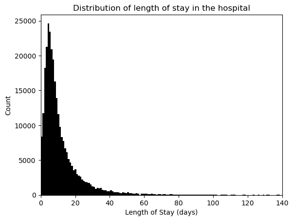

```python
plt.hist(df['length_of_stay'], bins=300, color = 'black')
plt.xlim(0, 140)
plt.title('Distribution of length of stay in the hospital')
plt.ylabel('Count')
plt.xlabel('Length of Stay (days)')
plt.tick_params(top=False, right=False)
plt.show();
```

[figure not shown]

```python
# Median length of stay by admission type and admission type categories

los_admission_data = df.groupby('admission_type')['length_of_stay'].apply(lambda x: x.values).tolist()

# Boxplot
fig, ax = plt.subplots(figsize=(8, 4))
ax.boxplot(los_admission_data, medianprops=dict(color='blue'))
ax.set_ylim((0, 20))
ax.set_ylabel('Length of Stay')
range_yticks = np.arange(5, 32, 5)
plt.yticks(range_yticks)
#ax.set_xlabel('Insurance')
plt.xticks([1, 2, 3, 4], ['Elective', 'Emergency', 'Newborn', 'Urgent'])
ax.tick_params(left=False, right=False)
ax.set_title('Comparison of Admission Type')
#plt.tight_layout()
plt.show()
```

[figure not shown]

```python
# Median length of stay by discharge location and discharge location categories

los_discharge_data = df.groupby('discharge_location')['length_of_stay'].apply(lambda x: x.values).tolist()

# Boxplot
fig, ax = plt.subplots(figsize=(8, 4))
ax.boxplot(los_discharge_data, medianprops=dict(color='blue'))
ax.set_ylim((0, 20))
ax.set_ylabel('Length of Stay (days)')
range_yticks = np.arange(5, 26, 5)
plt.yticks(range_yticks)
#ax.set_xlabel('Insurance')
plt.xticks([1, 2, 3, 4], ['Home', 'Home Health Care', 'Hospital', 'Other'])
ax.tick_params(left=False, right=False)
ax.set_title('Comparison of Discharge Location')
#plt.tight_layout()
plt.show()
```

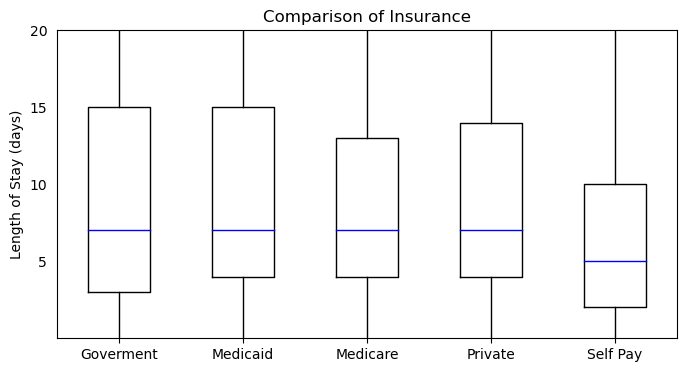

```python
# Median length of stay by insurance and insurance categories

los_ins_data = df.groupby('insurance')['length_of_stay'].apply(lambda x: x.values).tolist()

# Boxplot
fig, ax = plt.subplots(figsize=(8, 4))
ax.boxplot(los_ins_data, medianprops=dict(color='blue'))
ax.set_ylim((0, 20))
ax.set_ylabel('Length of Stay (days)')
range_yticks = np.arange(5, 22, 5)
plt.yticks(range_yticks)
#ax.set_xlabel('Insurance')
plt.xticks([1, 2, 3, 4, 5], ['Goverment', 'Medicaid', 'Medicare', 'Private', 'Self Pay'])
ax.tick_params(left=False, right=False)
ax.set_title('Comparison of Insurance')
#plt.tight_layout()
plt.show()
```

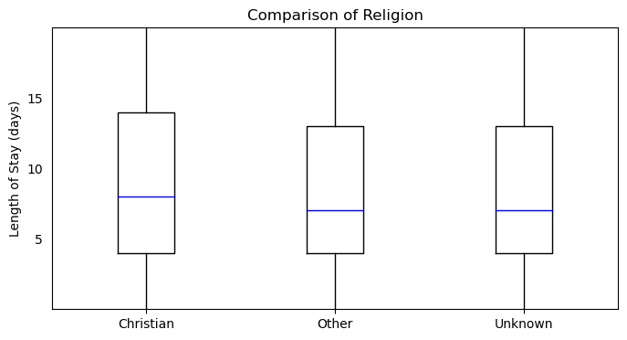

```python
# Median length of stay by religion and religion categories

los_religion_data = df.groupby('religion')['length_of_stay'].apply(lambda x: x.values).tolist()

# Boxplot
fig, ax = plt.subplots(figsize=(8, 4))
ax.boxplot(los_religion_data, medianprops=dict(color='blue'))
ax.set_ylim((0, 20))
ax.set_ylabel('Length of Stay (days)')
range_yticks = np.arange(5, 16, 5)
plt.yticks(range_yticks)
#ax.set_xlabel('Insurance')
plt.xticks([1, 2, 3], ['Christian', 'Other', 'Unknown'])
ax.tick_params(left=False, right=False)
ax.set_title('Comparison of Religion')
#plt.tight_layout()
plt.show()
```

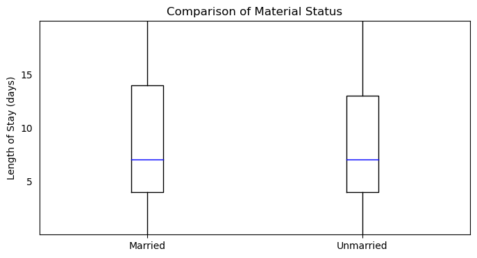

```python
# Median length of stay by material status and material status categories

los_martital_data = df.groupby('marital_status')['length_of_stay'].apply(lambda x: x.values).tolist()

# Boxplot
fig, ax = plt.subplots(figsize=(8, 4))
ax.boxplot(los_martital_data, medianprops=dict(color='blue'))
ax.set_ylim((0, 20))
ax.set_ylabel('Length of Stay (days)')
range_yticks = np.arange(5, 20, 5)
plt.yticks(range_yticks)
#ax.set_xlabel('Insurance')
plt.xticks([1, 2], ['Married', 'Unmarried'])
ax.tick_params(left=False, right=False)
ax.set_title('Comparison of Material Status')
#plt.tight_layout()
plt.show()
```

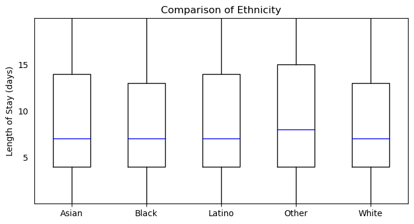

```python
# Median length of stay by ethnicity and ethnicity categories

los_ethnicity_data = df.groupby('ethnicity')['length_of_stay'].apply(lambda x: x.values).tolist()
medianprops=dict(color='black')
# Boxplot
fig, ax = plt.subplots(figsize=(8, 4))
ax.boxplot(los_ethnicity_data, medianprops=dict(color='blue'))
ax.set_ylim((0, 20))
ax.set_ylabel('Length of Stay (days)')
range_yticks = np.arange(5, 16, 5)
plt.yticks(range_yticks)
#ax.set_xlabel('Insurance')
plt.xticks([1, 2, 3, 4, 5], ['Asian', 'Black', 'Latino', 'Other', 'White'])
ax.tick_params(left=False, right=False)
ax.set_title('Comparison of Ethnicity')
#plt.tight_layout()
plt.show()
```

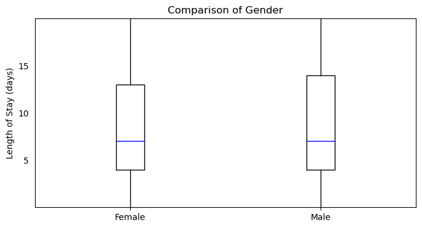

```python
# Median length of stay by gender and gender categories

los_gender_data = df.groupby('gender')['length_of_stay'].apply(lambda x: x.values).tolist()

# Boxplot
fig, ax = plt.subplots(figsize=(8, 4))
ax.boxplot(los_gender_data, medianprops=dict(color='blue'))
ax.set_ylim((0, 20))
ax.set_ylabel('Length of Stay (days)')
range_yticks = np.arange(5, 16, 5)
plt.yticks(range_yticks)
#ax.set_xlabel('Insurance')
plt.xticks([1, 2], ['Female', 'Male'])
ax.tick_params(left=False, right=False)
ax.set_title('Comparison of Gender')
#plt.tight_layout()
plt.show()
```

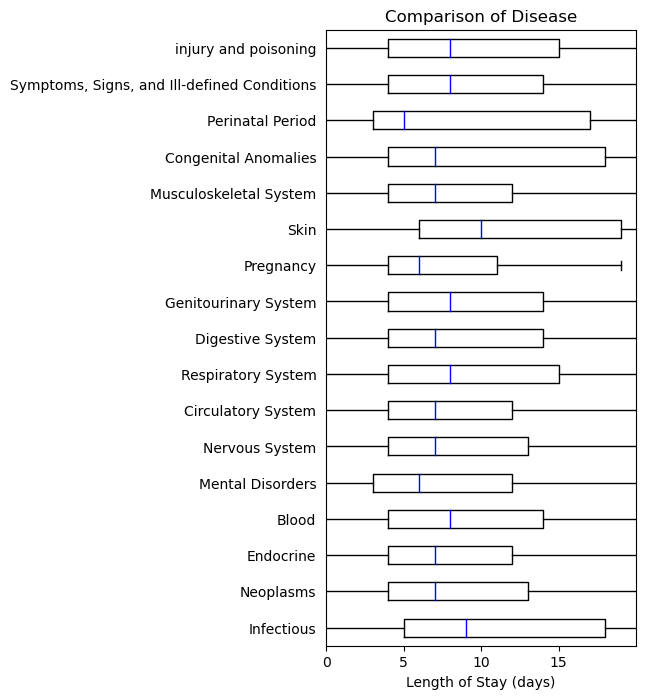

```python
# Median length of stay by disease and disease classification

los_disease_data = df.groupby('diseases_classification')['length_of_stay'].apply(lambda x: x.values).tolist()

# Boxplot
fig, ax = plt.subplots(figsize=(4, 8))
ax.boxplot(los_disease_data, vert=False, medianprops=dict(color='blue'))
ax.set_xlim((0, 20))
#ax.set_ylabel('Insurance')
range_xticks = np.arange(0, 20, 5)
plt.xticks(range_xticks)
ax.set_xlabel('Length of Stay (days)')
plt.yticks([1, 2, 3, 4, 5, 6, 7, 8, 9, 10, 11, 12, 13, 14, 15, 16, 17], ['Infectious', 'Neoplasms', 'Endocrine', 'Blood', 'Mental Disorders', 'Nervous System', 'Circulatory System',
 'Respiratory System', 'Digestive System', 'Genitourinary System', 'Pregnancy', 'Skin', 'Musculoskeletal System',
'Congenital Anomalies','Perinatal Period', 'Symptoms, Signs, and Ill-defined Conditions', 'injury and poisoning'])
ax.tick_params(left=False, right=False)
ax.set_title('Comparison of Disease')
#plt.tight_layout()
plt.show()
```

```python
#sns.scatterplot(data=df, x="comorbidities", y="median_los_comorbidities", color='black')
```

```python
#sns.lineplot(data=df, x="comorbidities", y="median_los_comorbidities", color='black', ci= None)
```

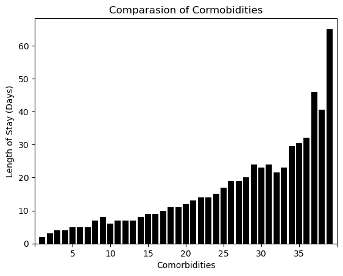

```python
figure = sns.barplot(data=df, x="comorbidities", y="median_los_comorbidities", color='black', ci = None)
range_xticks = np.arange(-1, 40, 5)
plt.xticks(range_xticks)
plt.xlabel("Comorbidities")
plt.ylabel("Length of Stay (Days)")
plt.title("Comparasion of Cormobidities")
plt.show(figure)
```